# Untitled

DengYibo-20531483

2018年4月8日

## 1. Load and check data

### 1.1 Load the library

```r
library(readr)
library(dplyr)
library(randomForest)
```

```r
library(ggplot2)
library(lattice)
library(mice)
library(party)
library(MLmetrics)
```

### 1.2 Load the data

```r
setwd("C:\\Users\\Administrator\\Desktop\\mini-project2")
train = read_csv("train.csv")
test = read_csv("test.csv")
```

### 1.3 Fix some errors in this dataset

#### The following fixes SibSp/Parch values for two passengers (Id=280 and Id=1284). Because a 16 year old can’t have a 13 year old son! He goes further and confirm it with historical data.

```r
train$SibSp[train$PassengerId==280] = 0
train$Parch[train$PassengerId==280] = 2
test$SibSp[test$PassengerId==1284] = 1
test$Parch[test$PassengerId==1284] = 1
```

### 1.4 Combine data

```r
test$Survived = rep(NA, dim(test)[1])
total = bind_rows(train, test)
```

### 1.5 Transform Survived to a categorical target for binary classification

```r
total$Survived = as.factor(total$Survived)
total$Sex = as.factor(total$Sex)
total$Pclass = as.ordered(total$Pclass)
total$Embarked = as.ordered(total$Embarked)
```

## 2. Exploring some important variables

### 2.1 Pclass

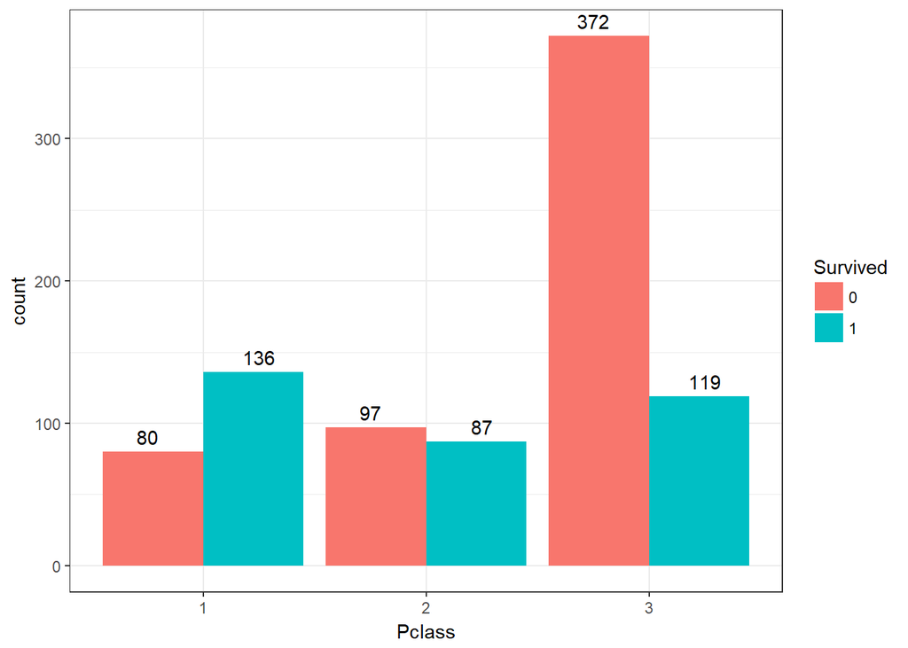

```r
ggplot(total[!is.na(total$Survived),], aes(x = Pclass, fill = Survived)) +
geom_bar(stat='count', position='dodge') +
labs(x = 'Pclass') + theme_bw() +
scale_x_discrete (limits = c('1', '2', '3')) +
geom_text(stat = "count", aes(label = ..count..), position=position_dodge(width=1), vjust=-0.5)
```

#### Pclass=1的乘客大部分幸存，Pclass=2的乘客接近一半幸存，而Pclass=3的乘客只有不到25%幸存。

### 2.2 Surname

```r
total$FamilySize = total$SibSp + total$Parch + 1

total$Surname = sapply(total$Name, FUN=function(x) {strsplit(x, split='[,.]')[[1]][1]})
total$FamilyID = paste(as.character(total$FamilySize), total$Surname, sep="")
total$FamilyID[total$FamilySize <= 2] = 'Small'
famIDs = data.frame(table(total$FamilyID))
famIDs = famIDs[famIDs$Freq <= 2,]
total$FamilyID[total$FamilyID %in% famIDs$Var1] = 'Small'
total$FamilyID = factor(total$FamilyID)
```

### 2.3 Title

#### The name variable contains some information about title and family(e.g. Surname), so we create some significative variables.

```r
total$title =  gsub("^.*, (.*?)\\..*$", "\\1", total$Name)
table(total$title)
```

```
##
##         Capt          Col          Don         Dona           Dr
##            1            4            1            1            8
##     Jonkheer         Lady        Major       Master         Miss
##            1            1            2           61          260
##         Mlle          Mme           Mr          Mrs           Ms
##            2            1          757          197            2
##          Rev          Sir the Countess
##            8            1            1
```

#### The table shows that there are too many titles to analyze, so we try to reduce the number of titles.

```r
total$title[total$title == 'Capt']  = 'Officer'
total$title[total$title == 'Col']   = 'Officer'
total$title[total$title == 'Don']   = 'Officer'
total$title[total$title == 'Dr']    = 'Officer'
total$title[total$title == 'Major']    = 'Officer'
total$title[total$title == 'Rev']    = 'Officer'

total$title[total$title == 'Lady']  = 'Miss'
total$title[total$title == 'Mlle']  = 'Miss'
total$title[total$title == 'Mme']   = 'Miss'
total$title[total$title == 'Ms']    = 'Miss'

total$title[total$title == 'Jonkheer']    = 'Mr'
total$title[total$title == 'Sir']    = 'Mr'

total$title[total$title == 'Dona']  = 'Mrs'
total$title[total$title == 'the Countess'] = 'Mrs'

total$title = as.factor(total$title)

table(total$Sex, total$title)
```

```
##
##          Master Miss  Mr Mrs Officer
##   female      0  266   0 199       1
##   male       61    0 759   0      23
```

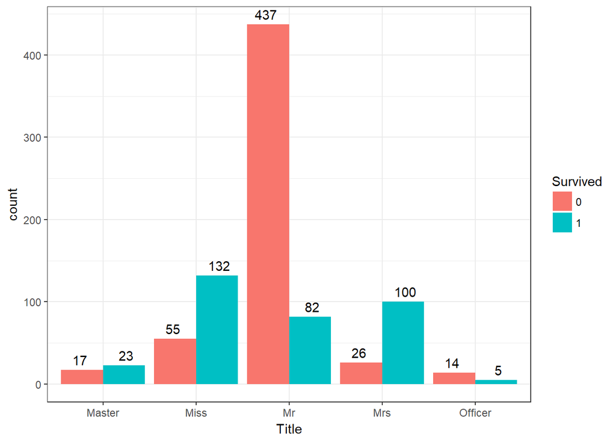

```r
ggplot(total[!is.na(total$Survived),], aes(x = title, fill = Survived)) +
geom_bar(stat='count', position='dodge') +
labs(x = 'Title') + theme_bw() +
scale_x_discrete (limits = c('Master', 'Miss', 'Mr', 'Mrs', 'Officer')) +
geom_text(stat = "count", aes(label = ..count..), position=position_dodge(width=1), vjust=-0.5)
```

### 2.4 Sex

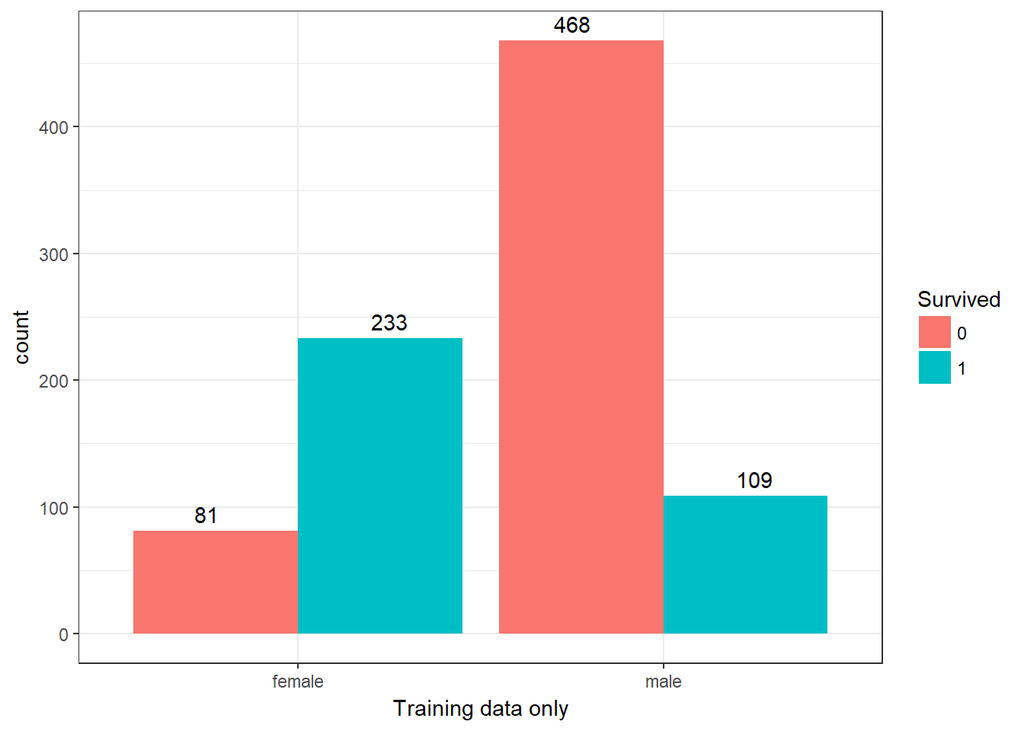

```r
ggplot(total[!is.na(total$Survived),], aes(x = Sex, fill = Survived)) +
geom_bar(stat='count', position='dodge') + theme_bw() +
labs(x = 'Training data only') +
geom_text(stat = "count", aes(label = ..count..), position=position_dodge(width=1), vjust=-0.5)
```

```r
468/(468+81)
```

```
## [1] 0.852459
```

#### The 85.25% of dead people are male within the training data.

### 2.5 Age

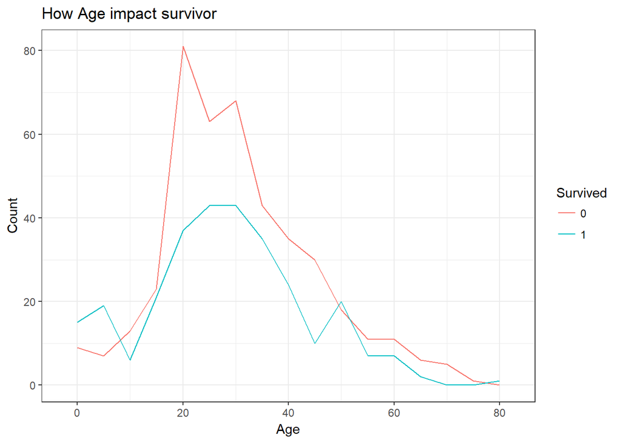

```r
ggplot(total[!is.na(total$Survived),], aes(x = Age, color=Survived)) +
  geom_line(aes(label = ..count..), stat = 'bin', binwidth=5)  + theme_bw() +
  labs(title = "How Age impact survivor", x = "Age", y = "Count", fill = "Survived")
```

### 2.6 Family Size

#### The variables sibsp and parch represent the family size, we can create a new variable to combine these relation.

```r
total$FamilySize = total$SibSp + total$Parch + 1

total$FamilySized[total$FamilySize == 1] = 'solo'
```

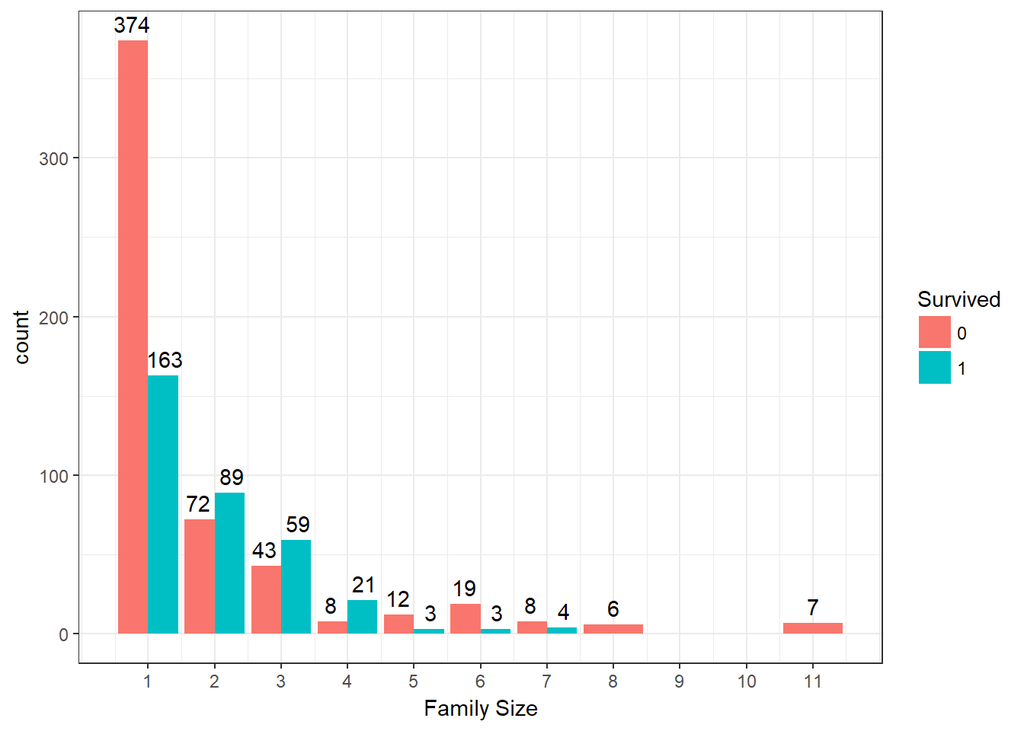

```r
total$FamilySized[total$FamilySize == 2] = 'duble'
total$FamilySized[total$FamilySize >=3 & total$FamilySize <=4] = 'group'
total$FamilySized[total$FamilySize >= 5] = 'large group'
total$FamilySized = as.factor(total$FamilySized)

ggplot(total[!is.na(total$Survived),], aes(x = FamilySize, fill = Survived)) +
geom_bar(stat='count', position='dodge') +
scale_x_continuous(breaks=c(1:11)) +
labs(x = 'Family Size') + theme_bw()+
geom_text(stat = "count", aes(label = ..count..), position=position_dodge(width=1), vjust=-0.5)
```

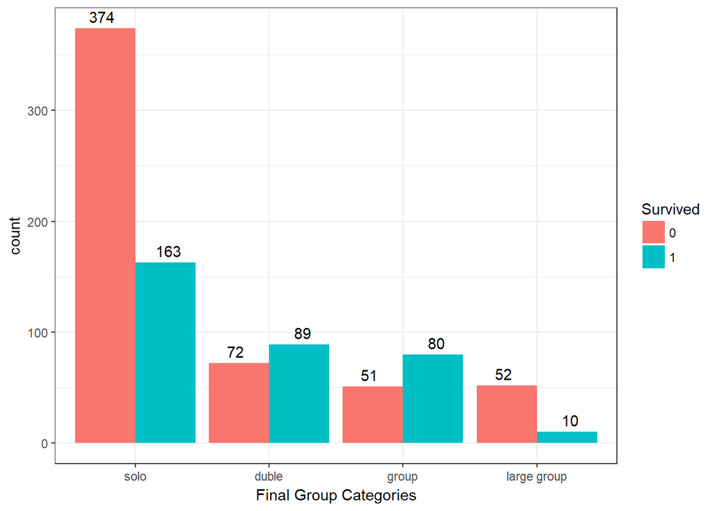

```r
ggplot(total[!is.na(total$Survived),], aes(x = FamilySized, fill = Survived)) +
geom_bar(stat='count', position='dodge') +
labs(x = 'Final Group Categories') + theme_bw() +
scale_x_discrete (limits = c('solo', 'duble', 'group', 'large group')) +
geom_text(stat = "count", aes(label = ..count..), position=position_dodge(width=1), vjust=-0.5)
```

### 2.7 Ticket

#### 票号相同的乘客，是一家人，很可能同时幸存或者同时遇难。现将所有乘客按照Ticket分为两组，一组是使用单独票号，另一组是与他人共享票号，并统计出各组的幸存与遇难人数。

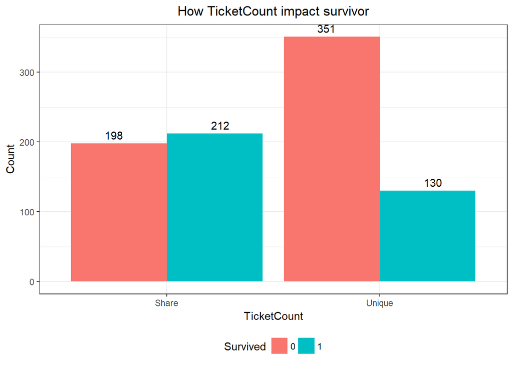

```r
ticket.count = aggregate(total$Ticket, by = list(total$Ticket), function(x) sum(!is.na(x)))
total$TicketCount = apply(total, 1, function(x) ticket.count[which(ticket.count[, 1] == x['Ticket']), 2])
total$TicketCount = factor(sapply(total$TicketCount, function(x) ifelse(x > 1, 'Share', 'Unique')))
ggplot(total[!is.na(total$Survived),], mapping = aes(x = TicketCount, y = ..count.., fill=Survived)) +
geom_bar(stat = 'count', position='dodge') +
xlab('TicketCount') +
ylab('Count') + theme_bw() +
ggtitle('How TicketCount impact survivor') +
geom_text(stat = "count", aes(label = ..count..), position=position_dodge(width=1), , vjust=-0.5) +
theme(plot.title = element_text(hjust = 0.5), legend.position="bottom")
```

### 2.8 Embarked

#### The city of Embarked may be another significant factors, due to the difference of the level of economy.

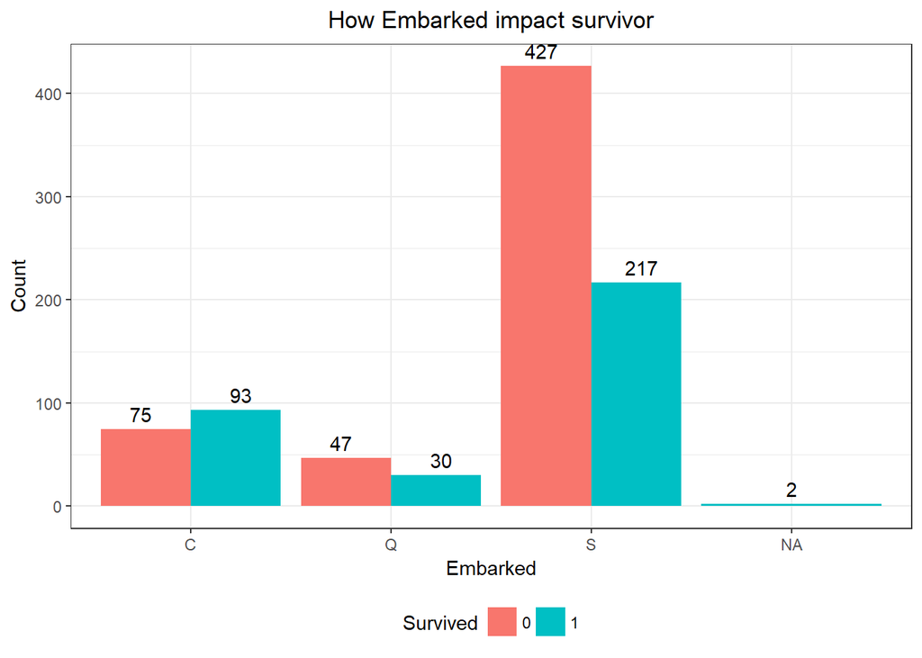

```r
ggplot(total[!is.na(total$Survived),], mapping = aes(x = Embarked, y = ..count.., fill = Survived)) +
geom_bar(stat = 'count', position='dodge') +
xlab('Embarked') +
ylab('Count') + theme_bw() +
ggtitle('How Embarked impact survivor') +
geom_text(stat = "count", aes(label = ..count..), position=position_dodge(width=1), , vjust=-0.5) +
theme(plot.title = element_text(hjust = 0.5), legend.position="bottom")
```

## 3. Missing data

### 3.1 Fare values: 1 passengers(PassengerId=1044)

```r
total[1044,]
```

```
## # A tibble: 1 x 18
##   PassengerId Survived Pclass               Name    Sex   Age SibSp Parch
##         <int>   <fctr>  <ord>              <chr> <fctr> <dbl> <dbl> <dbl>
## 1        1044     <NA>      3 Storey, Mr. Thomas   male  60.5     0     0
## # ... with 10 more variables: Ticket <chr>, Fare <dbl>, Cabin <chr>,
## #   Embarked <ord>, FamilySize <dbl>, Surname <chr>, FamilyID <fctr>,
## #   title <fctr>, FamilySized <fctr>, TicketCount <fctr>
```

#### This passenger embarked from ‘S’, and his Pclass was 3. We reasonably use the value of median for this Pclass and embarkment to replace the NA Fare.

```r
total$Fare[1044] = median(total[total$Pclass == '3' & total$Embarked == 'S', ]$Fare, na.rm = TRUE)
```

### 3.2 Embarked values: 2 passengers(PassengerId=62, 830)

#### Embarked could be important to Fare, as different Embarkement cities mean longer or shorter journeys.

```r
rbind(total[62,],total[830,])
```

```
## # A tibble: 2 x 18
##   PassengerId Survived Pclass                                      Name
##         <int>   <fctr>  <ord>                                     <chr>
## 1          62        1      1                       Icard, Miss. Amelie
## 2         830        1      1 Stone, Mrs. George Nelson (Martha Evelyn)
## # ... with 14 more variables: Sex <fctr>, Age <dbl>, SibSp <dbl>,
## #   Parch <dbl>, Ticket <chr>, Fare <dbl>, Cabin <chr>, Embarked <ord>,
## #   FamilySize <dbl>, Surname <chr>, FamilyID <fctr>, title <fctr>,
## #   FamilySized <fctr>, TicketCount <fctr>
```

#### We use the most common code to replace NAs in the Embarked feature.

```r
total$Embarked[c(62, 830)] = 'S'
```

### 3.3 Cabin values: 77% missing

#### We don’t use this variable to predict.

### 3.4 Age values: 20% missing

#### We choose mice package to predict the missing data.

```r
set.seed(319)
mice.Age = mice(total[, names(total) %in% c('Pclass','Sex','Age','Fare','Embarked','FamilySize', 'FamilySized',  'title', 'FamilyID', 'TicketCount')], method='rf')
mice.output = complete(mice.Age)
```

#### Let’s compare the results we get with the original distribution of passenger ages to ensure that nothing has gone completely awry.

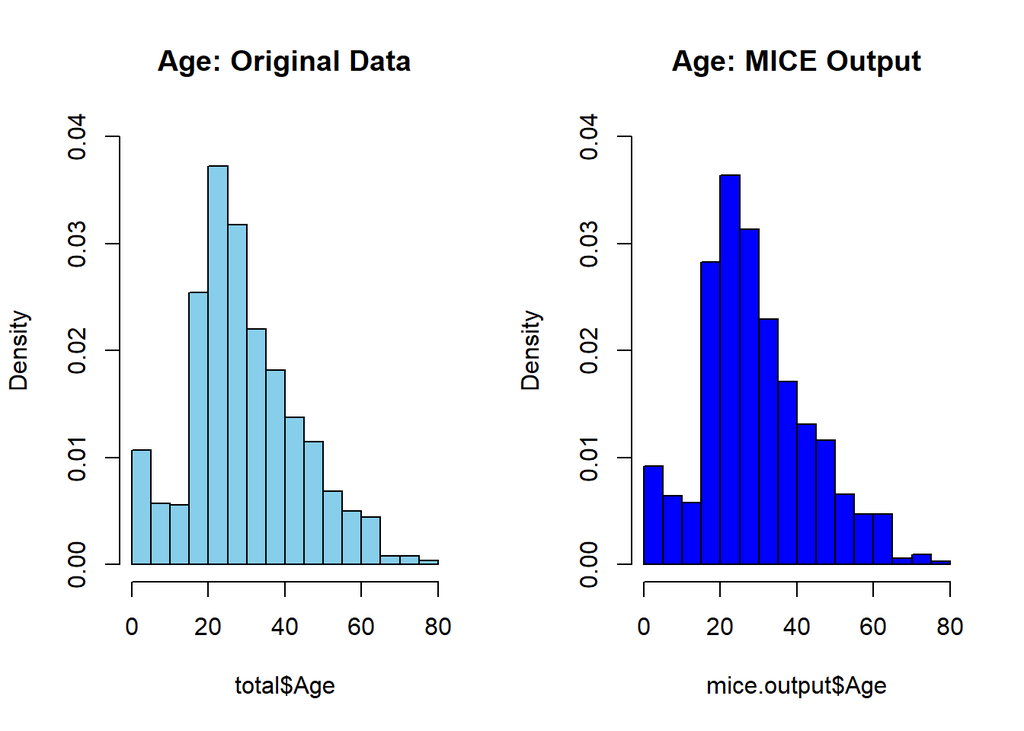

```r
par(mfrow=c(1,2))
hist(total$Age, freq=F, main='Age: Original Data',
  col='skyblue', ylim=c(0,0.04))
hist(mice.output$Age, freq=F, main='Age: MICE Output',
  col='blue', ylim=c(0,0.04))
```

#### It seems reasonable, thus we use the mice model to predict the missing value of Age.

```r
total$Age = mice.output$Age
```

## 4. Prediction

# Random Forest model

```r
set.seed(10)
model = cforest(as.factor(Survived) ~ Pclass + Sex + Age + Fare + Embarked + FamilySize + title + FamilyID + TicketCount, data = total[1:891, ], controls=cforest_unbiased(ntree=1000, mtry=3))

cv.summarize <- function(data.true, data.predict) {
  print(paste('Recall:', Recall(data.true, data.predict)))
  print(paste('Precision:', Precision(data.true, data.predict)))
  print(paste('Accuracy:', Accuracy(data.predict, data.true)))
  print(paste('AUC:', AUC(data.predict, data.true)))
 }
set.seed(10)
cv.test.sample = sample(1:nrow(train), as.integer(0.3 * nrow(train)), replace = TRUE)
cv.test = total[cv.test.sample,]
cv.prediction = predict(model, cv.test, OOB=TRUE, type = "response")
cv.summarize(cv.test$Survived, cv.prediction)
```

```
## [1] "Recall: 0.925714285714286"
## [1] "Precision: 0.870967741935484"
## [1] "Accuracy: 0.861423220973783"
## [1] "AUC: 0.832422360248447"
```

## 5. Conclusion

```r
predict.result = predict(model, total[(1+nrow(train)):(nrow(total)), ], OOB=TRUE, type = "response")
output = data.frame(PassengerId = test$PassengerId, Survived = predict.result)
write.csv(output, file = "final.csv", row.names = FALSE)
```